# Donor Profile: Norad - Norwegian Agency for Development Cooperation

## Transaction Volatility

Norad channels an average transaction size of 5.6 million USD through 24 annual transactions, starkly contrasting with top-10 donors averaging 2.7 million USD over nearly 600 transactions yearly. This funding pattern reveals significant volatility and potential gaps impacting consistent program delivery. The limited transaction frequency constrains agility and scalability in fast-evolving humanitarian contexts. This volatility poses a strategic risk for emergency responsiveness and resource predictability, critical to donor priorities. Investing in stabilizing Norad’s transaction cadence offers an impact multiplier, leveraging its high transaction value while addressing consistency. Increasing transaction frequency could enhance risk diversification and program reach, unlocking unspent capacities and improving accountability. We recommend targeting partnerships that support scalable, regularized funding flows while preserving large-scale transaction advantages. Mobilizing donor commitments to smooth Norad’s funding volatility represents a strategic priority to enhance operational resilience and maximize humanitarian impact.

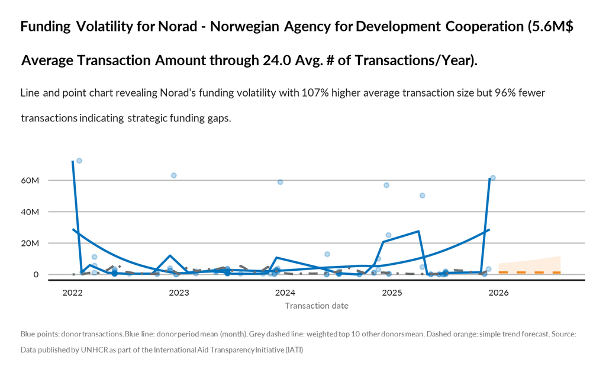

TRUE